# p8105_hw6_kp3127

2025-12-02

# Problem 1

Cleaning the dataset

```r
homi_df=read.csv("./homicide-data.csv") %>%
  janitor::clean_names() %>%
  mutate(
    city_state = str_c(city, ", ", state),
    victim_age = as.numeric(victim_age),
    solved = if_else(disposition == "Open/No arrest", 0, 1),
  ) %>%
  filter(
    !city_state %in% c("Dallas, TX", "Phoenix, AZ",
                       "Kansas City, MO", "Tulsa, AL"),
    victim_race %in% c("White", "Black"),
    !is.na(victim_age),
    !is.na(victim_sex),
    !is.na(solved)
  ) %>%
  mutate(
    victim_race = fct_relevel(victim_race, "White"),
    victim_sex  = fct_relevel(victim_sex, "Female")
  )
```

Logistic regression for Baltimore

```r
baltimore_df = homi_df %>%
  filter(city_state == "Baltimore, MD")

baltimore_fit =
  glm(
    solved~victim_age + victim_sex + victim_race,
    data   = baltimore_df,
    family = binomial()
  )

baltimore_or =
  baltimore_fit %>%
  tidy(conf.int = TRUE, exponentiate = TRUE) %>%
  filter(term == "victim_sexMale") %>%
  select(term, estimate, conf.low, conf.high)

baltimore_or |>
  knitr::kable(digits = 3)
```

| term | estimate | conf.low | conf.high |
| --- | --- | --- | --- |
| victim_sexMale | 0.355 | 0.267 | 0.468 |

Logistic regression for all

```r
city_or_df <-
  homi_df |>
  group_by(city_state) |>
  nest() |>
  mutate(
    model = map(
      data,
      ~ .x |>
        mutate(
          victim_sex  = fct_relevel(victim_sex, "Female"),
          victim_race = fct_relevel(victim_race, "White")
        ) |>
        glm(
          solved ~ victim_age + victim_sex + victim_race,
          data   = _,
          family = binomial()
        )
    ),
    results = map(
      model,
      ~ tidy(.x, conf.int = TRUE, exponentiate = TRUE)
    )
  ) |>
  unnest(results) |>
  filter(term == "victim_sexMale") |>
  select(city_state,estimate,conf.low,conf.high) |>
  arrange(city_state)
```

Plots

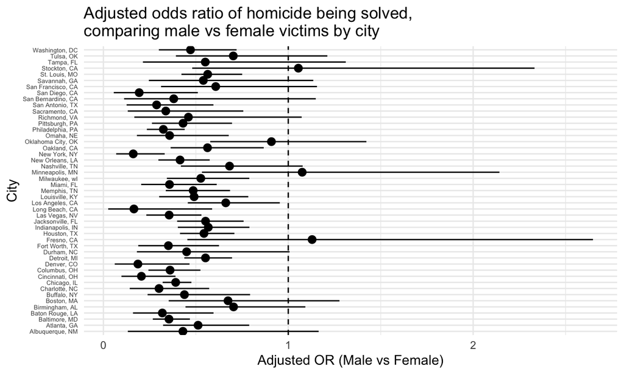

```r
ggplot(city_or_df, aes(x = city_state,
                            y = estimate)) +
  geom_pointrange(aes(ymin = conf.low, ymax = conf.high)) +
  geom_hline(yintercept = 1, linetype = "dashed") +
  coord_flip() +
  labs(
    x = "City",
    y = "Adjusted OR (Male vs Female)",
    title = "Adjusted odds ratio of homicide being solved,\ncomparing male vs female victims by city"
  ) +
  theme_minimal() +
  theme(
    axis.text.y = element_text(size = 5)
  )
```

# Problem 2

```r
library(p8105.datasets)
data("weather_df")

weather_df %>%
  drop_na(tmax, tmin, prcp)
```

```
## # A tibble: 2,171 × 6
##    name           id          date        prcp  tmax  tmin
##    <chr>          <chr>       <date>     <dbl> <dbl> <dbl>
##  1 CentralPark_NY USW00094728 2021-01-01   157   4.4   0.6
##  2 CentralPark_NY USW00094728 2021-01-02    13  10.6   2.2
##  3 CentralPark_NY USW00094728 2021-01-03    56   3.3   1.1
##  4 CentralPark_NY USW00094728 2021-01-04     5   6.1   1.7
##  5 CentralPark_NY USW00094728 2021-01-05     0   5.6   2.2
##  6 CentralPark_NY USW00094728 2021-01-06     0   5     1.1
##  7 CentralPark_NY USW00094728 2021-01-07     0   5    -1
##  8 CentralPark_NY USW00094728 2021-01-08     0   2.8  -2.7
##  9 CentralPark_NY USW00094728 2021-01-09     0   2.8  -4.3
## 10 CentralPark_NY USW00094728 2021-01-10     0   5    -1.6
## # ℹ 2,161 more rows
```

```r
boot_results =
  weather_df %>%
  bootstrap(n = 5000, id = "boot_id") %>%
  mutate(
    model  = map(strap, ~ lm(tmax ~ tmin + prcp, data = .x)),
    glance = map(model, glance),
    tidy   = map(model, tidy)
  ) %>%
  mutate(
    r2 = map_dbl(glance, "r.squared"),
    beta_ratio = map_dbl(
      tidy,
      ~ {
        b1 <- filter(.x, term == "tmin")  %>%  pull(estimate)
        b2 <- filter(.x, term == "prcp") %>%  pull(estimate)
        b1 / b2
      }
    )
  ) %>%
  select(boot_id, r2, beta_ratio)
```

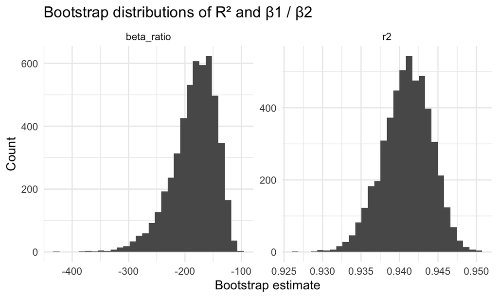

```r
boot_long =
  boot_results %>%
  pivot_longer(
    cols = c(r2, beta_ratio),
    names_to = "parameter",
    values_to = "estimate"
  )

ggplot(boot_long, aes(x = estimate)) +
  geom_histogram(bins = 30) +
  facet_wrap(~ parameter, scales = "free") +
  labs(
    x = "Bootstrap estimate",
    y = "Count",
    title = "Bootstrap distributions of R² and β1 / β2"
  ) +
  theme_minimal()
```

```r
boot_CI =
  boot_results %>%
  summarize(
    r2_lower   = quantile(r2, 0.025),
    r2_upper   = quantile(r2, 0.975),
    ratio_lower = quantile(beta_ratio, 0.025),
    ratio_upper = quantile(beta_ratio, 0.975)
  )
boot_CI %>%
  knitr::kable(digits = 3)
```

| r2_lower | r2_upper | ratio_lower | ratio_upper |
| --- | --- | --- | --- |
| 0.934 | 0.947 | -279.749 | -125.686 |

The bootstrap distribution of R² is approximately symmetric and tightly concentrated around 0.94, indicating that the model consistently explains a large proportion of the variability in daily maximum temperature. The 95% bootstrap CI for R² is (0.934, 0.947), so in repeated samples we would expect R² to fall in roughly this 93–95% range.

# Problem 3

Clean the data

```r
birthweight_df=read_csv("./birthweight.csv") %>%
  mutate(
    babysex = factor(babysex, labels = c("male", "female")),
    frace   = factor(frace),
    mrace   = factor(mrace),
    malform = factor(malform),
  )
```

Propose my own regression model for birthweight: I aimed to include variables that reflect infant size at birth, gestational age, and maternal characteristics that plausibly influence fetal growth.

```r
bw_main <- lm(
  bwt ~ bhead + blength + babysex + gaweeks +
    ppbmi + wtgain + momage + smoken + mrace,
  data = birthweight_df
)
summary(bw_main)
```

```
##
## Call:
## lm(formula = bwt ~ bhead + blength + babysex + gaweeks + ppbmi +
##     wtgain + momage + smoken + mrace, data = birthweight_df)
##
## Residuals:
##      Min       1Q   Median       3Q      Max
## -1075.58  -186.53    -4.51   177.81  2396.14
##
## Coefficients:
##                 Estimate Std. Error t value Pr(>|t|)
## (Intercept)   -5776.9052   102.7701 -56.212  < 2e-16 ***
## bhead           132.0940     3.4664  38.106  < 2e-16 ***
## blength          76.4761     2.0193  37.872  < 2e-16 ***
## babysexfemale    31.9763     8.5071   3.759 0.000173 ***
## gaweeks          11.0829     1.4691   7.544 5.52e-14 ***
## ppbmi             6.8413     1.3445   5.088 3.76e-07 ***
## wtgain            4.1554     0.3965  10.481  < 2e-16 ***
## momage            1.9746     1.1705   1.687 0.091689 .
## smoken           -4.6227     0.5886  -7.854 5.04e-15 ***
## mrace2         -142.5266     9.8060 -14.535  < 2e-16 ***
## mrace3         -104.7026    42.7859  -2.447 0.014439 *
## mrace4         -134.9229    18.8711  -7.150 1.02e-12 ***
## ---
## Signif. codes:  0 '***' 0.001 '**' 0.01 '*' 0.05 '.' 0.1 ' ' 1
##
## Residual standard error: 274.3 on 4330 degrees of freedom
## Multiple R-squared:  0.7139, Adjusted R-squared:  0.7132
## F-statistic: 982.4 on 11 and 4330 DF,  p-value: < 2.2e-16
```

The model explains roughly 71% of the variability in birthweight (djusted R² = 0.713), which indicates fairly strong explanatory power. The overall F-test is highly significant (F(11, 4330) = 982.4, p < 0.001), providing strong evidence that the set of predictors jointly improves prediction of birthweight compared with an intercept-only model.

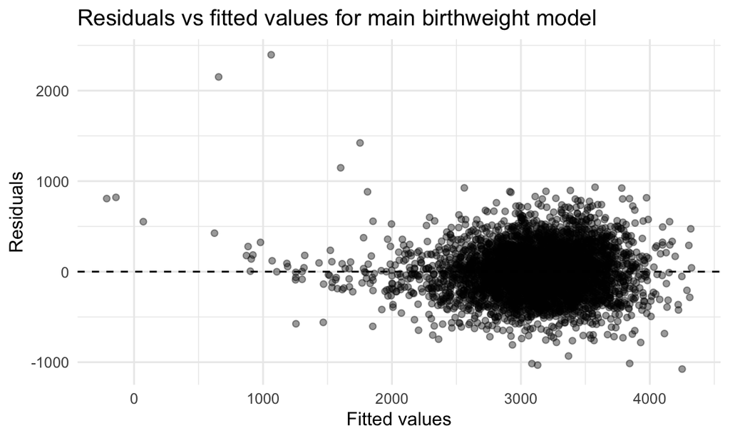

```r
bw_main_aug <-
  birthweight_df |>
  add_predictions(bw_main) |>
  add_residuals(bw_main)

ggplot(bw_main_aug, aes(x = pred, y = resid)) +
  geom_point(alpha = 0.4) +
  geom_hline(yintercept = 0, linetype = "dashed") +
  labs(
    x = "Fitted values",
    y = "Residuals",
    title = "Residuals vs fitted values for main birthweight model"
  ) +
  theme_minimal()
```

The residuals are generally centered around zero across the range of fitted birthweights, and there is no strong curvature or systematic pattern, which supports the linearity assumption. The spread of residuals is fairly constant for most fitted values, although there are a few extreme outliers at very low and very high fitted birthweights.

Compare my model to two models

```r
mod_A <- lm(bwt ~ blength + gaweeks, data = birthweight_df)

mod_B <- lm(bwt ~ bhead * blength * babysex, data = birthweight_df)

mod_C <- bw_main
```

CV

```r
cv_df <-
  crossv_mc(birthweight_df, 100) %>%
  mutate(
    train = map(train, as_tibble),
    test  = map(test,  as_tibble),
    mod_A = map(train, ~ lm(bwt ~ blength + gaweeks, data = .x)),
    mod_B = map(train, ~ lm(bwt ~ bhead * blength * babysex, data = .x)),
    mod_C = map(train, ~ lm(
      bwt ~ bhead + blength + babysex + gaweeks +
        ppbmi + wtgain + momage + smoken + mrace,
      data = .x
    )),
    rmse_A = map2_dbl(mod_A, test, ~ rmse(.x, .y)),
    rmse_B = map2_dbl(mod_B, test, ~ rmse(.x, .y)),
    rmse_C = map2_dbl(mod_C, test, ~ rmse(.x, .y))
  )

cv_long =
  cv_df %>%
  select(starts_with("rmse_")) %>%
  pivot_longer(
    everything(),
    names_to = "model",
    values_to = "rmse"
  ) %>%
  mutate(model = recode(model,
                        rmse_A = "A: blength + gaweeks",
                        rmse_B = "B: bhead*blength*babysex",
                        rmse_C = "C: my model"))
```

```r
cv_summary =
  cv_long %>%
  group_by(model) %>%
  summarise(
    mean_rmse = mean(rmse),
    sd_rmse   = sd(rmse)
  )

cv_summary %>%
  knitr::kable()
```

| model | mean_rmse | sd_rmse |
| --- | --- | --- |
| A: blength + gaweeks | 332.2341 | 13.863437 |
| B: bhead*blength*babysex | 288.9950 | 9.481895 |
| C: my model | 274.7941 | 8.626247 |

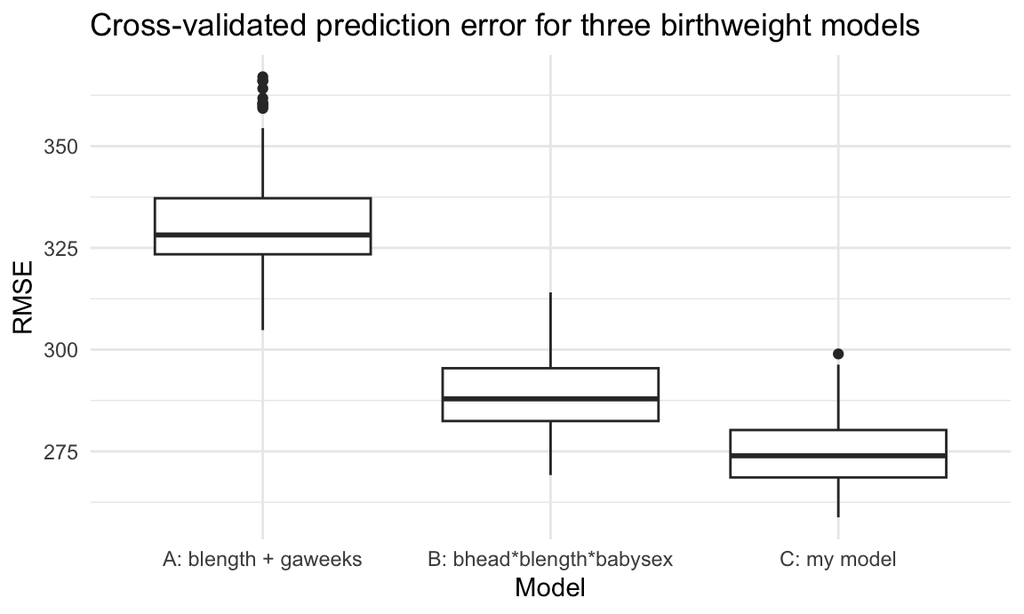

```r
ggplot(cv_long, aes(x = model, y = rmse)) +
  geom_boxplot() +
  labs(
    x = "Model",
    y = "RMSE",
    title = "Cross-validated prediction error for three birthweight models"
  ) +
  theme_minimal()
```

The cross-validated RMSEs show clear differences in out-of-sample performance across the three models. Model A, which only includes birth length and gestational age, has the highest prediction error (mean RMSE = 332) and the greatest variability, suggesting substantial underfitting. Model B, which includes head circumference, birth length, infant sex, and their interactions, performs better (mean RMSE = 288). My proposed model (Model C) has the lowest mean RMSE (mean RMSE = 275) and the tightest distribution, indicating the best and most stable predictive performance. Overall, adding additional maternal and infant covariates in Model C improves prediction beyond both the very simple model and the interaction-only model.